# United States Census Analysis

Rahul kaushik

June30,2018

### The data here is for the "Census Income" dataset, which contains data on adults from the 1994 census. This data is labeled with whether the person's yearly income is above or below 50K (and we are trying to model and predict this).

[figure not shown]

# Dataset description

1.Listing of attributes: >50K, <=50K.

2.age: continuous.

3.workclass: Private, Self-emp-not-inc, Self-emp-inc, Federal-gov, Local-gov, State-gov, Without-pay, Never-worked.

4.fnlwgt: continuous.

5.education: Bachelors, Some-college, 11th, HS-grad, Prof-school, Assoc-acdm, Assoc-voc, 9th, 7th-8th, 12th, Masters, 1st-4th,10th, Doctorate, 5th-6th, Preschool.

6.education-num: continuous.

7.marital-status: Married-civ-spouse, Divorced, Never-married, Separated, Widowed, Married-spouse-absent, Married-AF-spouse.

8.occupation: Tech-support, Craft-repair, Other-service, Sales, Exec-managerial, Prof-specialty, Handlers-cleaners, Machine-op-inspct, Adm-clerical, Farming-fishing, Transport-moving, Priv-house-serv, Protective-serv, Armed-Forces.

9.relationship: Wife, Own-child, Husband, Not-in-family, Other-relative, Unmarried.

10.race: White, Asian-Pac-Islander, Amer-Indian-Eskimo, Other, Black.

11.sex: Female, Male.

12.capital-gain: continuous.

13.capital-loss: continuous.

14.hours-per-week: continuous.

15.native-country: United-States, Cambodia, England, Puerto-Rico, Canada, Germany, Outlying-US(Guam-USVI-etc), India, Japan, Greece, South, China, Cuba, Iran, Honduras, Philippines, Italy, Poland, Jamaica, Vietnam, Mexico, Portugal, Ireland, France, Dominican-Republic, Laos, Ecuador, Taiwan, Haiti, Columbia, Hungary, Guatemala, Nicaragua, Scotland, Thailand, Yugoslavia, El-Salvador, Trinadad&Tobago, Peru, Hong, Holand-Netherlands.

## Libraray Imports

```python
import pandas as pd
import seaborn as sns
import matplotlib.pyplot as plt
%matplotlib inline
```

# Load the data

```python
data=pd.read_csv("E:\study material\census.csv",names=['Age','Workclass','fnlwgt','Education','Education-num','Marital-status','Occupation','Relationship','Race','Sex','Capital_gain','Capital_loss','Hours_per_week','Native country','Yearly_income'])
```

### Let's view our imported dataset by using the head function which displays the first five rows of the dataframe.

```python
data.head()
```

|  | Age | Workclass | fnlwgt | Education | Education-num | Marital-status | Occupation | Relationship | Race | Sex | Capital_gain | Capital_loss | Hours_per_week | Native country | Yearly_income |
| --- | --- | --- | --- | --- | --- | --- | --- | --- | --- | --- | --- | --- | --- | --- | --- |
| 0 | 39 | State-gov | 77516 | Bachelors | 13 | Never-married | Adm-clerical | Not-in-family | White | Male | 2174 | 0 | 40 | United-States | <=50K |
| 1 | 50 | Self-emp-not-inc | 83311 | Bachelors | 13 | Married-civ-spouse | Exec-managerial | Husband | White | Male | 0 | 0 | 13 | United-States | <=50K |
| 2 | 38 | Private | 215646 | HS-grad | 9 | Divorced | Handlers-cleaners | Not-in-family | White | Male | 0 | 0 | 40 | United-States | <=50K |
| 3 | 53 | Private | 234721 | 11th | 7 | Married-civ-spouse | Handlers-cleaners | Husband | Black | Male | 0 | 0 | 40 | United-States | <=50K |
| 4 | 28 | Private | 338409 | Bachelors | 13 | Married-civ-spouse | Prof-specialty | Wife | Black | Female | 0 | 0 | 40 | Cuba | <=50K |

### Here is the shape of the dataset

```python
data.shape
```

```
(32561, 15)
```

### Here is the size of the dataset

```python
data.size
```

```
488415
```

### Here is the statistical description of our dataset.

```python
data.describe(include='all')
```

|  | Age | Workclass | fnlwgt | Education | Education-num | Marital-status | Occupation | Relationship | Race | Sex | Capital_gain | Capital_loss | Hours_per_week | Native country | Yearly_income |
| --- | --- | --- | --- | --- | --- | --- | --- | --- | --- | --- | --- | --- | --- | --- | --- |
| count | 32561.000000 | 32561 | 3.256100e+04 | 32561 | 32561.000000 | 32561 | 32561 | 32561 | 32561 | 32561 | 32561.000000 | 32561.000000 | 32561.000000 | 32561 | 32561 |
| unique | NaN | 9 | NaN | 16 | NaN | 7 | 15 | 6 | 5 | 2 | NaN | NaN | NaN | 42 | 2 |
| top | NaN | Private | NaN | HS-grad | NaN | Married-civ-spouse | Prof-specialty | Husband | White | Male | NaN | NaN | NaN | United-States | <=50K |
| freq | NaN | 22696 | NaN | 10501 | NaN | 14976 | 4140 | 13193 | 27816 | 21790 | NaN | NaN | NaN | 29170 | 24720 |
| mean | 38.581647 | NaN | 1.897784e+05 | NaN | 10.080679 | NaN | NaN | NaN | NaN | NaN | 1077.648844 | 87.303830 | 40.437456 | NaN | NaN |
| std | 13.640433 | NaN | 1.055500e+05 | NaN | 2.572720 | NaN | NaN | NaN | NaN | NaN | 7385.292085 | 402.960219 | 12.347429 | NaN | NaN |
| min | 17.000000 | NaN | 1.228500e+04 | NaN | 1.000000 | NaN | NaN | NaN | NaN | NaN | 0.000000 | 0.000000 | 1.000000 | NaN | NaN |
| 25% | 28.000000 | NaN | 1.178270e+05 | NaN | 9.000000 | NaN | NaN | NaN | NaN | NaN | 0.000000 | 0.000000 | 40.000000 | NaN | NaN |
| 50% | 37.000000 | NaN | 1.783560e+05 | NaN | 10.000000 | NaN | NaN | NaN | NaN | NaN | 0.000000 | 0.000000 | 40.000000 | NaN | NaN |
| 75% | 48.000000 | NaN | 2.370510e+05 | NaN | 12.000000 | NaN | NaN | NaN | NaN | NaN | 0.000000 | 0.000000 | 45.000000 | NaN | NaN |
| max | 90.000000 | NaN | 1.484705e+06 | NaN | 16.000000 | NaN | NaN | NaN | NaN | NaN | 99999.000000 | 4356.000000 | 99.000000 | NaN | NaN |

```python
data.info()
```

```
<class 'pandas.core.frame.DataFrame'>
RangeIndex: 32561 entries, 0 to 32560
Data columns (total 15 columns):
Age               32561 non-null int64
Workclass         32561 non-null object
fnlwgt            32561 non-null int64
Education         32561 non-null object
Education-num     32561 non-null int64
Marital-status    32561 non-null object
Occupation        32561 non-null object
Relationship      32561 non-null object
Race              32561 non-null object
Sex               32561 non-null object
Capital_gain      32561 non-null int64
Capital_loss      32561 non-null int64
Hours_per_week    32561 non-null int64
Native country    32561 non-null object
Yearly_income     32561 non-null object
dtypes: int64(6), object(9)
memory usage: 3.7+ MB
```

```python
data.isnull().sum()
```

```
Age               0
Workclass         0
fnlwgt            0
Education         0
Education-num     0
Marital-status    0
Occupation        0
Relationship      0
Race              0
Sex               0
Capital_gain      0
Capital_loss      0
Hours_per_week    0
Native country    0
Yearly_income     0
dtype: int64
```

## This shows that luckily we don't have any missing value but we have ? at some places so we will replace it

```python
data["Occupation"]=data["Occupation"].replace({' ?':'Self_employed'})
```

```python
data=data.loc[data['Occupation']!='Self_employed']
```

```python
data.head()
```

|  | Age | Workclass | fnlwgt | Education | Education-num | Marital-status | Occupation | Relationship | Race | Sex | Capital_gain | Capital_loss | Hours_per_week | Native country | Yearly_income |
| --- | --- | --- | --- | --- | --- | --- | --- | --- | --- | --- | --- | --- | --- | --- | --- |
| 0 | 39 | State-gov | 77516 | Bachelors | 13 | Never-married | Adm-clerical | Not-in-family | White | Male | 2174 | 0 | 40 | United-States | <=50K |
| 1 | 50 | Self-emp-not-inc | 83311 | Bachelors | 13 | Married-civ-spouse | Exec-managerial | Husband | White | Male | 0 | 0 | 13 | United-States | <=50K |
| 2 | 38 | Private | 215646 | HS-grad | 9 | Divorced | Handlers-cleaners | Not-in-family | White | Male | 0 | 0 | 40 | United-States | <=50K |
| 3 | 53 | Private | 234721 | 11th | 7 | Married-civ-spouse | Handlers-cleaners | Husband | Black | Male | 0 | 0 | 40 | United-States | <=50K |
| 4 | 28 | Private | 338409 | Bachelors | 13 | Married-civ-spouse | Prof-specialty | Wife | Black | Female | 0 | 0 | 40 | Cuba | <=50K |

```python
data.shape
```

```
(30718, 15)
```

```python
print(data['Native country'].mode())
```

```
0     United-States
dtype: object
```

```python
data["Native country"]=data["Native country"].replace({' ?':'Unknown'})
```

```python
data=data.loc[data['Native country']!='Unknown']
```

```python
data.shape
```

```
(30162, 15)
```

```python
print(data['Occupation'].unique())
```

```
[' Adm-clerical' ' Exec-managerial' ' Handlers-cleaners' ' Prof-specialty'
 ' Other-service' ' Sales' ' Transport-moving' ' Farming-fishing'
 ' Machine-op-inspct' ' Tech-support' ' Craft-repair' ' Protective-serv'
 ' Armed-Forces' ' Priv-house-serv']
```

```python
print(data['Native country'].unique())
```

```
[' United-States' ' Cuba' ' Jamaica' ' India' ' Mexico' ' Puerto-Rico'
 ' Honduras' ' England' ' Canada' ' Germany' ' Iran' ' Philippines'
 ' Poland' ' Columbia' ' Cambodia' ' Thailand' ' Ecuador' ' Laos'
 ' Taiwan' ' Haiti' ' Portugal' ' Dominican-Republic' ' El-Salvador'
 ' France' ' Guatemala' ' Italy' ' China' ' South' ' Japan' ' Yugoslavia'
 ' Peru' ' Outlying-US(Guam-USVI-etc)' ' Scotland' ' Trinadad&Tobago'
 ' Greece' ' Nicaragua' ' Vietnam' ' Hong' ' Ireland' ' Hungary'
 ' Holand-Netherlands']
```

## Now there are no ? marks in our dataset

```python
data['Net_Capital']=data['Capital_gain'] - data['Capital_loss']
```

```python
data.head()
```

|  | Age | Workclass | fnlwgt | Education | Education-num | Marital-status | Occupation | Relationship | Race | Sex | Capital_gain | Capital_loss | Hours_per_week | Native country | Yearly_income | Net_Capital |
| --- | --- | --- | --- | --- | --- | --- | --- | --- | --- | --- | --- | --- | --- | --- | --- | --- |
| 0 | 39 | State-gov | 77516 | Bachelors | 13 | Never-married | Adm-clerical | Not-in-family | White | Male | 2174 | 0 | 40 | United-States | <=50K | 2174 |
| 1 | 50 | Self-emp-not-inc | 83311 | Bachelors | 13 | Married-civ-spouse | Exec-managerial | Husband | White | Male | 0 | 0 | 13 | United-States | <=50K | 0 |
| 2 | 38 | Private | 215646 | HS-grad | 9 | Divorced | Handlers-cleaners | Not-in-family | White | Male | 0 | 0 | 40 | United-States | <=50K | 0 |
| 3 | 53 | Private | 234721 | 11th | 7 | Married-civ-spouse | Handlers-cleaners | Husband | Black | Male | 0 | 0 | 40 | United-States | <=50K | 0 |
| 4 | 28 | Private | 338409 | Bachelors | 13 | Married-civ-spouse | Prof-specialty | Wife | Black | Female | 0 | 0 | 40 | Cuba | <=50K | 0 |

```python
data.shape
```

```
(30162, 16)
```

```python
data.drop(['Capital_gain'], axis = 1, inplace = True)
```

```python
data.drop(['Capital_loss'], axis = 1, inplace = True)
```

```python
data.head()
```

|  | Age | Workclass | fnlwgt | Education | Education-num | Marital-status | Occupation | Relationship | Race | Sex | Hours_per_week | Native country | Yearly_income | Net_Capital |
| --- | --- | --- | --- | --- | --- | --- | --- | --- | --- | --- | --- | --- | --- | --- |
| 0 | 39 | State-gov | 77516 | Bachelors | 13 | Never-married | Adm-clerical | Not-in-family | White | Male | 40 | United-States | <=50K | 2174 |
| 1 | 50 | Self-emp-not-inc | 83311 | Bachelors | 13 | Married-civ-spouse | Exec-managerial | Husband | White | Male | 13 | United-States | <=50K | 0 |
| 2 | 38 | Private | 215646 | HS-grad | 9 | Divorced | Handlers-cleaners | Not-in-family | White | Male | 40 | United-States | <=50K | 0 |
| 3 | 53 | Private | 234721 | 11th | 7 | Married-civ-spouse | Handlers-cleaners | Husband | Black | Male | 40 | United-States | <=50K | 0 |
| 4 | 28 | Private | 338409 | Bachelors | 13 | Married-civ-spouse | Prof-specialty | Wife | Black | Female | 40 | Cuba | <=50K | 0 |

## Looking at the components/features individually i.e. univariate analysis

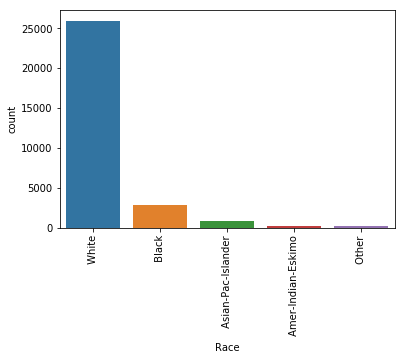

```python
sns.countplot(x='Race',data=data)
plt.xlabel='race'
plt.ylabel='no. of people'
plt.xticks(rotation='vertical')
plt.show()
```

### In a new report, the Census Bureau found the U.S. population has become more racially and ethnically diverse. The country's Hispanic population increased by 2.1 percent to 58.9 million in recent years and the Asian-American population -- the nation's fastest-growing racial group -- increased by 3.1 percent to 22.2 million during that time.

## This graph tells us the majority of white people there.

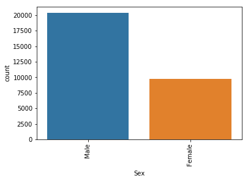

```python
sns.countplot(x='Sex',data=data)
plt.xlabel='Sex'
plt.ylabel='no. of people'
plt.xticks(rotation='vertical')
plt.show()
```

## The data collected contains more males aproximately double the number of females and ultimately telling us the sex ratio.

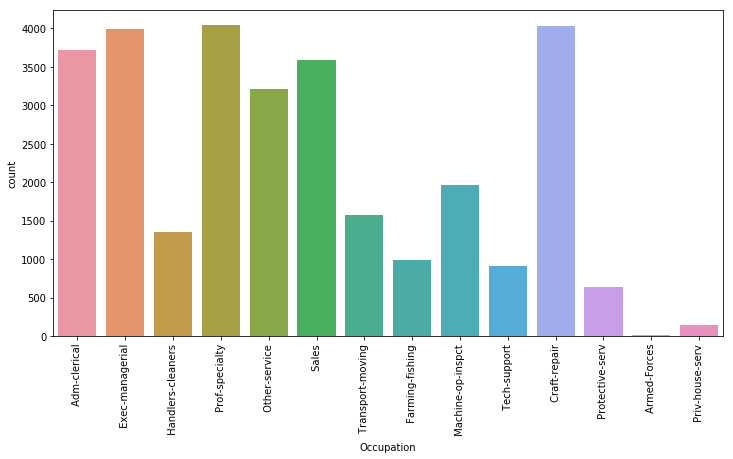

```python
plt.figure(figsize=(12,6))
sns.countplot(x='Occupation',data=data)
plt.xlabel='Occupation'
plt.ylabel='no. of people'
plt.xticks(rotation='vertical')
plt.show()
```

### The maximum number of people are employed as prof-speciality and craft-repair followed by Exec-managerial

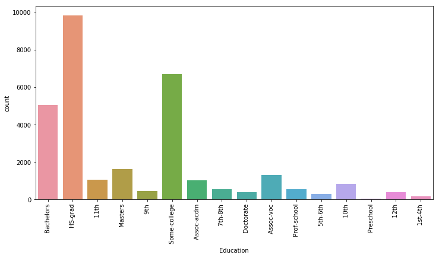

```python
plt.figure(figsize=(12,6))
sns.countplot(x='Education',data=data)
plt.xlabel='Education'
plt.ylabel='no. of people'
plt.xticks(rotation='vertical')
plt.show()
```

## Most of the people are HS-grad followed by Some-college graduate in number and then are the bachelors

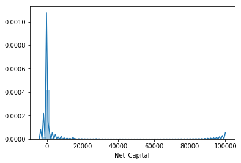

```python
sns.distplot(data['Net_Capital']);
```

## This plot displays both the histogram with the kernel density estimate (KDE) on top.

## The height of the histogram bars here is normed and shows the density rather than the number of examples in each bin.

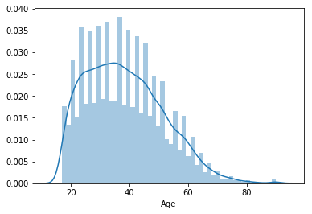

```python
sns.distplot(data['Age'])
```

### The Graph above represents the age distibution of the dataset available.

### We can easily figure out that the number of young people dominates whereas the aged and the children are very less in number.

### The stats like finding the age group in which maximum number of people are earning more than 50k yearly or so.

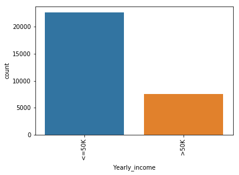

```python
sns.countplot(x='Yearly_income',data=data)
plt.xlabel='Yearly_income'
plt.ylabel='no. of people'
plt.xticks(rotation='vertical')
plt.show()
```

## Almost triple the number of people have there yearly income<=50k than the number of people having earning more than 50k. Now we will look at the relations between two or more features and figure out the correlations and dependencies

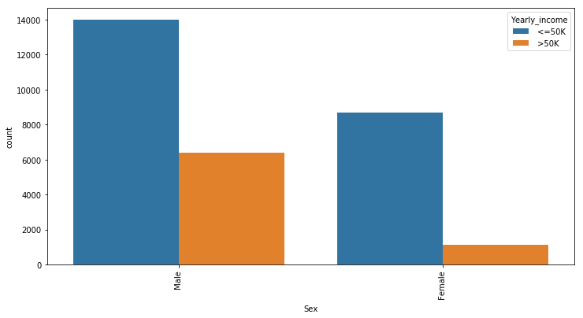

```python
plt.figure(figsize=(12,6))
sns.countplot(x="Sex", hue="Yearly_income",data=data)
plt.xlabel='Sex'
plt.ylabel='Yearly income'
plt.xticks(rotation='vertical')
plt.show()
```

## One third of the Males are earning >50k however the fraction of females earning more than 50k yearly is very less

## The graph between Age and fnlwgt is plotted below

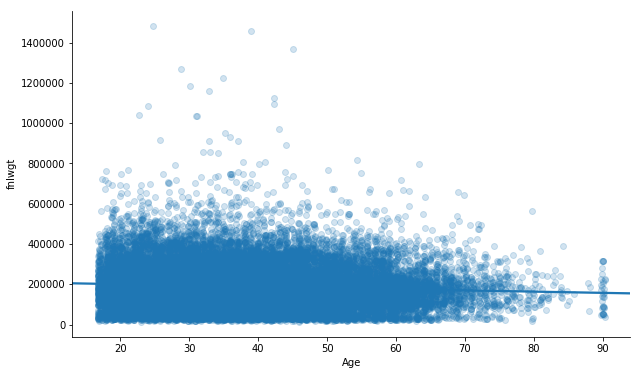

```python
plt.figure(figsize=(10,6))
sns.regplot(x='Age', y='fnlwgt', data=data, x_jitter=0.3, scatter_kws={'alpha':0.2})
sns.despine()
```

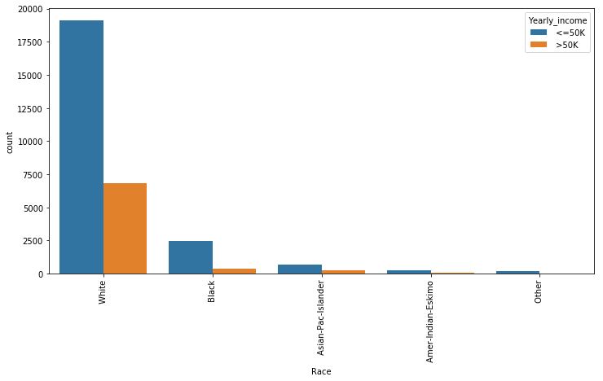

```python
plt.figure(figsize=(12,6))
sns.countplot(x="Race", hue="Yearly_income",data=data)
plt.xlabel='Race'
plt.ylabel='Yearly income'
plt.xticks(rotation='vertical')
plt.show()
```

## The maximum no. of people yearly income >50k are white. This may be because of the majority of the white people too.

### Now that education-num is defined according to the level of education of the candidate, we can use it to find a relation with the yearly income.

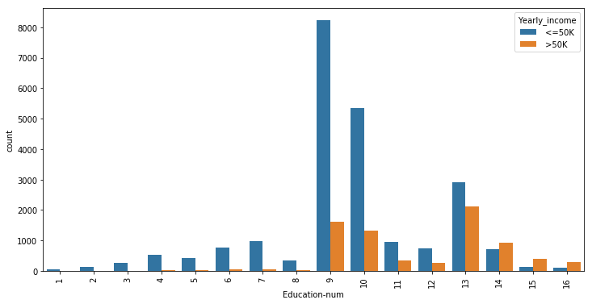

```python
plt.figure(figsize=(12,6))
sns.countplot(x="Education-num", hue="Yearly_income",data=data)
plt.xlabel='Education-num'
plt.ylabel='Yearly income'
plt.xticks(rotation='vertical')
plt.show()
```

## Now that's an important analysis, beacause it shows the relation between the education and the yearly income.Most of the people earning more than 50k yearly are HS-grad,Some college or Bachelor. The Bachelors are earning more than the Masters and Doctorate.

## Now first we will convert the possible attributes into numbers like Sex, 1 is for male 0 for female and likewise yearly income also using dummies

```python
data['Sex'] = pd.get_dummies(data['Sex'], drop_first=True)
```

```python
data['Yearly_income'] = pd.get_dummies(data['Yearly_income'], drop_first=True)
```

```python
data.head()
```

|  | Age | Workclass | fnlwgt | Education | Education-num | Marital-status | Occupation | Relationship | Race | Sex | Hours_per_week | Native country | Yearly_income | Net_Capital |
| --- | --- | --- | --- | --- | --- | --- | --- | --- | --- | --- | --- | --- | --- | --- |
| 0 | 39 | State-gov | 77516 | Bachelors | 13 | Never-married | Adm-clerical | Not-in-family | White | 1 | 40 | United-States | 0 | 2174 |
| 1 | 50 | Self-emp-not-inc | 83311 | Bachelors | 13 | Married-civ-spouse | Exec-managerial | Husband | White | 1 | 13 | United-States | 0 | 0 |
| 2 | 38 | Private | 215646 | HS-grad | 9 | Divorced | Handlers-cleaners | Not-in-family | White | 1 | 40 | United-States | 0 | 0 |
| 3 | 53 | Private | 234721 | 11th | 7 | Married-civ-spouse | Handlers-cleaners | Husband | Black | 1 | 40 | United-States | 0 | 0 |
| 4 | 28 | Private | 338409 | Bachelors | 13 | Married-civ-spouse | Prof-specialty | Wife | Black | 0 | 40 | Cuba | 0 | 0 |

```python
data['Education-num'].unique()
```

```
array([13,  9,  7, 14,  5, 10, 12,  4, 16, 11, 15,  3,  6,  1,  8,  2],
      dtype=int64)
```

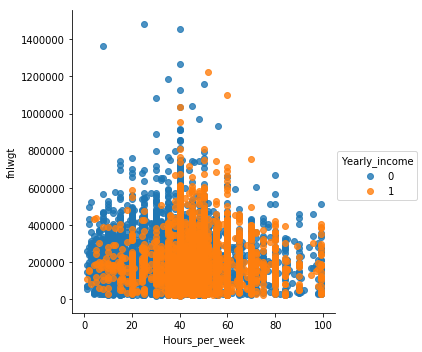

```python
sns.lmplot('Hours_per_week','fnlwgt',data=data,hue='Yearly_income',fit_reg=False);
```

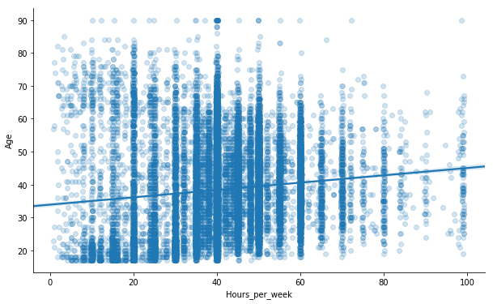

```python
plt.figure(figsize=(10,6))
sns.regplot(x='Hours_per_week', y='Age', data=data, x_jitter=0.3, scatter_kws={'alpha':0.2})
sns.despine()
```

## This shows that age and hours per week are not that related because neither the increasing age decreases the working hours nor increase

### Now that Education number is giving us complete information about the education of the candidate so we can drop Education column

```python
data.drop(['Education'], axis = 1, inplace = True)
```

```python
data.head()
```

|  | Age | Workclass | fnlwgt | Education-num | Marital-status | Occupation | Relationship | Race | Sex | Hours_per_week | Native country | Yearly_income | Net_Capital |
| --- | --- | --- | --- | --- | --- | --- | --- | --- | --- | --- | --- | --- | --- |
| 0 | 39 | State-gov | 77516 | 13 | Never-married | Adm-clerical | Not-in-family | White | 1 | 40 | United-States | 0 | 2174 |
| 1 | 50 | Self-emp-not-inc | 83311 | 13 | Married-civ-spouse | Exec-managerial | Husband | White | 1 | 13 | United-States | 0 | 0 |
| 2 | 38 | Private | 215646 | 9 | Divorced | Handlers-cleaners | Not-in-family | White | 1 | 40 | United-States | 0 | 0 |
| 3 | 53 | Private | 234721 | 7 | Married-civ-spouse | Handlers-cleaners | Husband | Black | 1 | 40 | United-States | 0 | 0 |
| 4 | 28 | Private | 338409 | 13 | Married-civ-spouse | Prof-specialty | Wife | Black | 0 | 40 | Cuba | 0 | 0 |

```python
from sklearn import preprocessing
le = preprocessing.LabelEncoder()
```

```python
le.fit(data['Race'])
list(le.classes_)
data['Race']=le.transform(data['Race'])
data['Race'].unique()
```

```
array([4, 2, 1, 0, 3], dtype=int64)
```

```python
data.head()
```

|  | Age | Workclass | fnlwgt | Education-num | Marital-status | Occupation | Relationship | Race | Sex | Hours_per_week | Native country | Yearly_income | Net_Capital |
| --- | --- | --- | --- | --- | --- | --- | --- | --- | --- | --- | --- | --- | --- |
| 0 | 39 | State-gov | 77516 | 13 | Never-married | Adm-clerical | Not-in-family | 4 | 1 | 40 | United-States | 0 | 2174 |
| 1 | 50 | Self-emp-not-inc | 83311 | 13 | Married-civ-spouse | Exec-managerial | Husband | 4 | 1 | 13 | United-States | 0 | 0 |
| 2 | 38 | Private | 215646 | 9 | Divorced | Handlers-cleaners | Not-in-family | 4 | 1 | 40 | United-States | 0 | 0 |
| 3 | 53 | Private | 234721 | 7 | Married-civ-spouse | Handlers-cleaners | Husband | 2 | 1 | 40 | United-States | 0 | 0 |
| 4 | 28 | Private | 338409 | 13 | Married-civ-spouse | Prof-specialty | Wife | 2 | 0 | 40 | Cuba | 0 | 0 |

## Now we can convert the marital-status into only two distinct options i.e. Complete-Family and Incomplete-Family

### Because Never-married,Separated,Widowed,Divorced,Married-spouse-absent are identified as in "Incomplete-Family" and Married-civ-spouse and Married-AF-spouse are defined as in "Complete-Family"

```python
data['Marital-status'].unique()
```

```
array([' Never-married', ' Married-civ-spouse', ' Divorced',
       ' Married-spouse-absent', ' Separated', ' Married-AF-spouse',
       ' Widowed'], dtype=object)
```

```python
data['Marital-status'] = data['Marital-status'].replace({' Married-AF-spouse':'Complete-family'})
data['Marital-status'] = data['Marital-status'].replace({' Married-civ-spouse':'Complete-family'})
data['Marital-status'] = data['Marital-status'].replace([' Divorced', ' Separated', ' Never-married', ' Married-spouse-absent', ' Widowed'],'Incomplete-Family')
```

```python
data['Marital-status'].unique()
```

```
array(['Incomplete-Family', 'Complete-family'], dtype=object)
```

## Now we can use dummies on it to convert into number

```python
data['Marital-status'] = pd.get_dummies(data['Marital-status'], drop_first=True)
```

```python
data.head(5)
```

|  | Age | Workclass | fnlwgt | Education-num | Marital-status | Occupation | Relationship | Race | Sex | Hours_per_week | Native country | Yearly_income | Net_Capital |
| --- | --- | --- | --- | --- | --- | --- | --- | --- | --- | --- | --- | --- | --- |
| 0 | 39 | State-gov | 77516 | 13 | 1 | Adm-clerical | Not-in-family | 4 | 1 | 40 | United-States | 0 | 2174 |
| 1 | 50 | Self-emp-not-inc | 83311 | 13 | 0 | Exec-managerial | Husband | 4 | 1 | 13 | United-States | 0 | 0 |
| 2 | 38 | Private | 215646 | 9 | 1 | Handlers-cleaners | Not-in-family | 4 | 1 | 40 | United-States | 0 | 0 |
| 3 | 53 | Private | 234721 | 7 | 0 | Handlers-cleaners | Husband | 2 | 1 | 40 | United-States | 0 | 0 |
| 4 | 28 | Private | 338409 | 13 | 0 | Prof-specialty | Wife | 2 | 0 | 40 | Cuba | 0 | 0 |

```python
data['Workclass'].unique()
```

```
array([' State-gov', ' Self-emp-not-inc', ' Private', ' Federal-gov',
       ' Local-gov', ' Self-emp-inc', ' Without-pay'], dtype=object)
```

```python
from sklearn import preprocessing
le = preprocessing.LabelEncoder()
```

```python
le.fit(data['Workclass'])
list(le.classes_)
```

```
[' Federal-gov',
 ' Local-gov',
 ' Private',
 ' Self-emp-inc',
 ' Self-emp-not-inc',
 ' State-gov',
 ' Without-pay']
```

```python
data['Workclass']=le.transform(data['Workclass'])
```

```python
data['Workclass'].unique()
```

```
array([5, 4, 2, 0, 1, 3, 6], dtype=int64)
```

```python
data.head()
```

|  | Age | Workclass | fnlwgt | Education-num | Marital-status | Occupation | Relationship | Race | Sex | Hours_per_week | Native country | Yearly_income | Net_Capital |
| --- | --- | --- | --- | --- | --- | --- | --- | --- | --- | --- | --- | --- | --- |
| 0 | 39 | 5 | 77516 | 13 | 1 | Adm-clerical | Not-in-family | 4 | 1 | 40 | United-States | 0 | 2174 |
| 1 | 50 | 4 | 83311 | 13 | 0 | Exec-managerial | Husband | 4 | 1 | 13 | United-States | 0 | 0 |
| 2 | 38 | 2 | 215646 | 9 | 1 | Handlers-cleaners | Not-in-family | 4 | 1 | 40 | United-States | 0 | 0 |
| 3 | 53 | 2 | 234721 | 7 | 0 | Handlers-cleaners | Husband | 2 | 1 | 40 | United-States | 0 | 0 |
| 4 | 28 | 2 | 338409 | 13 | 0 | Prof-specialty | Wife | 2 | 0 | 40 | Cuba | 0 | 0 |

```python
le.fit(data['Relationship'])
list(le.classes_)
data['Relationship']=le.transform(data['Relationship'])
```

```python
data['Relationship'].unique()
```

```
array([1, 0, 5, 3, 4, 2], dtype=int64)
```

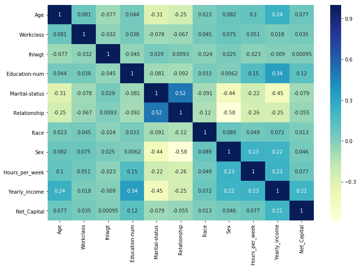

```python
plt.figure(figsize=(12,8))
sns.heatmap(data.corr(), cmap="YlGnBu",annot=True)
```

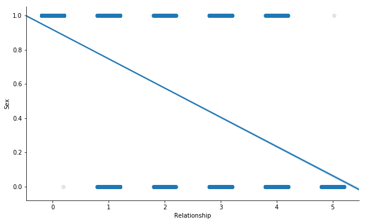

```python
plt.figure(figsize=(10,6))
sns.regplot(x='Relationship', y='Sex', data=data, x_jitter=0.2, scatter_kws={'alpha':0.15})
sns.despine()
```

### Here we can clearly see that there is a negative correlation between Sex and Relationship as depicted by the heatmap

```python
data['Occupation'].unique()
```

```
array([' Adm-clerical', ' Exec-managerial', ' Handlers-cleaners',
       ' Prof-specialty', ' Other-service', ' Sales', ' Transport-moving',
       ' Farming-fishing', ' Machine-op-inspct', ' Tech-support',
       ' Craft-repair', ' Protective-serv', ' Armed-Forces',
       ' Priv-house-serv'], dtype=object)
```

```python
le.fit(data['Occupation'])
list(le.classes_)
data['Occupation']=le.transform(data['Occupation'])
```

```python
data['Occupation'].unique()
```

```
array([ 0,  3,  5,  9,  7, 11, 13,  4,  6, 12,  2, 10,  1,  8],
      dtype=int64)
```

```python
data.head()
```

|  | Age | Workclass | fnlwgt | Education-num | Marital-status | Occupation | Relationship | Race | Sex | Hours_per_week | Native country | Yearly_income | Net_Capital |
| --- | --- | --- | --- | --- | --- | --- | --- | --- | --- | --- | --- | --- | --- |
| 0 | 39 | 5 | 77516 | 13 | 1 | 0 | 1 | 4 | 1 | 40 | United-States | 0 | 2174 |
| 1 | 50 | 4 | 83311 | 13 | 0 | 3 | 0 | 4 | 1 | 13 | United-States | 0 | 0 |
| 2 | 38 | 2 | 215646 | 9 | 1 | 5 | 1 | 4 | 1 | 40 | United-States | 0 | 0 |
| 3 | 53 | 2 | 234721 | 7 | 0 | 5 | 0 | 2 | 1 | 40 | United-States | 0 | 0 |
| 4 | 28 | 2 | 338409 | 13 | 0 | 9 | 5 | 2 | 0 | 40 | Cuba | 0 | 0 |

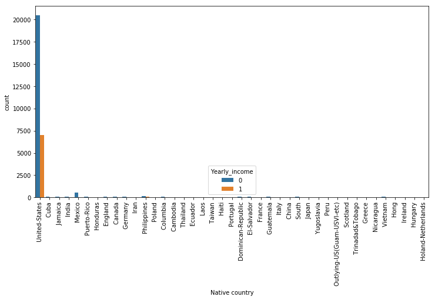

```python
plt.figure(figsize=(12,6))
sns.countplot(x='Native country',hue='Yearly_income',data=data)
plt.xlabel='Native country'
plt.ylabel='no. of matches'
plt.xticks(rotation='vertical')
plt.show()
```

### This plot can help us find out the top countries containing people with Yearly_earning more than 50k.

### However they are very less in number beacause majority of people are from United-States only.

```python
le.fit(data['Native country'])
list(le.classes_)
data['Native country']=le.transform(data['Native country'])
```

```python
data['Native country'].unique()
```

```
array([38,  4, 22, 18, 25, 32, 15,  8,  1, 10, 19, 29, 30,  3,  0, 36,  6,
       24, 35, 13, 31,  5,  7,  9, 12, 21,  2, 34, 23, 40, 28, 27, 33, 37,
       11, 26, 39, 16, 20, 17, 14], dtype=int64)
```

```python
data.drop(['fnlwgt'], axis = 1, inplace = True)
```

```python
data.info()
```

```
<class 'pandas.core.frame.DataFrame'>
Int64Index: 30162 entries, 0 to 32560
Data columns (total 12 columns):
Age               30162 non-null int64
Workclass         30162 non-null int64
Education-num     30162 non-null int64
Marital-status    30162 non-null uint8
Occupation        30162 non-null int64
Relationship      30162 non-null int64
Race              30162 non-null int64
Sex               30162 non-null uint8
Hours_per_week    30162 non-null int64
Native country    30162 non-null int64
Yearly_income     30162 non-null uint8
Net_Capital       30162 non-null int64
dtypes: int64(9), uint8(3)
memory usage: 3.6 MB
```

```python
data.head()
```

|  | Age | Workclass | Education-num | Marital-status | Occupation | Relationship | Race | Sex | Hours_per_week | Native country | Yearly_income | Net_Capital |
| --- | --- | --- | --- | --- | --- | --- | --- | --- | --- | --- | --- | --- |
| 0 | 39 | 5 | 13 | 1 | 0 | 1 | 4 | 1 | 40 | 38 | 0 | 2174 |
| 1 | 50 | 4 | 13 | 0 | 3 | 0 | 4 | 1 | 13 | 38 | 0 | 0 |
| 2 | 38 | 2 | 9 | 1 | 5 | 1 | 4 | 1 | 40 | 38 | 0 | 0 |
| 3 | 53 | 2 | 7 | 0 | 5 | 0 | 2 | 1 | 40 | 38 | 0 | 0 |
| 4 | 28 | 2 | 13 | 0 | 9 | 5 | 2 | 0 | 40 | 4 | 0 | 0 |

Feature selection, the process of finding and selecting the most useful features in a dataset, is a crucial step of the machine learning pipeline. Unnecessary features decrease training speed, decrease model interpretability, and, most importantly, decrease generalization performance on the test set.

#### As per this dataset is concerned one of the important points in feature selection is useful which says that the collinear features i.e. the features that are highly correlated can be removed. And from the domain knowledge we know that the marital status and the Relationship features are highly correlated.

```python
data['Yearly_income'].unique()
```

[output not shown]

```python
X=data.drop(['Yearly_income'], axis=1)
y=data['Yearly_income']
```

## Building a logistic regression model

# Train Test Split

```python
from sklearn.model_selection import  train_test_split
```

```python
X_train, X_test, y_train, y_test = train_test_split(X,y,test_size=0.36, random_state=38)
```

## Creating and Training the Model

```python
from sklearn.linear_model import LogisticRegression
```

```python
log = LogisticRegression()
```

```python
log.fit(X_train, y_train)
```

```
LogisticRegression(C=1.0, class_weight=None, dual=False, fit_intercept=True,
          intercept_scaling=1, max_iter=100, multi_class='ovr', n_jobs=1,
          penalty='l2', random_state=None, solver='liblinear', tol=0.0001,
          verbose=0, warm_start=False)
```

## Predictions from our Model

```python
predictions = log.predict(X_test)
```

## Model Evaluation

```python
print('Score:')
score = log.score(X_test, y_test)
score
```

```
Score:
```

```
0.8347914172575743
```

```python
import sklearn.metrics as met
```

```python
print('Accuracy Score: ')
met.accuracy_score(y_test, predictions)
```

```
Accuracy Score:
```

```
0.8347914172575743
```

## Model getting an accuracy score of 0.83 is a good model.

```python
cm = met.confusion_matrix(y_test, predictions)
print('Confusion Matrix')
cm
```

```
Confusion Matrix
```

```
array([[7611,  630],
       [1164, 1454]], dtype=int64)
```

```python
from sklearn.metrics import roc_auc_score
roc_auc_score(y_test, predictions)
```

```
0.7394693787764304
```

```python
print('Classification Report: ')
cr = met.classification_report(y_test, predictions)
print(cr)
```

```
Classification Report:
             precision    recall  f1-score   support

          0       0.87      0.92      0.89      8241
          1       0.70      0.56      0.62      2618

avg / total       0.83      0.83      0.83     10859
```

## K Nearest-Neighbours

### Train Test Split

```python
from sklearn.neighbors import KNeighborsClassifier
neigh = KNeighborsClassifier()
```

```python
neigh.fit(X_train, y_train)
```

```
KNeighborsClassifier(algorithm='auto', leaf_size=30, metric='minkowski',
           metric_params=None, n_jobs=1, n_neighbors=5, p=2,
           weights='uniform')
```

## Predictions from our model

```python
predictions = neigh.predict(X_test)
```

## Model Evaluation

```python
print('Score:')
score = neigh.score(X_test, y_test)
score
```

```
Score:
```

```
0.8359885809006354
```

```python
from sklearn.metrics import confusion_matrix
cm = confusion_matrix(y_test, predictions)
print('Confusion Matrix:')
cm
```

```
Confusion Matrix:
```

```
array([[7503,  738],
       [1043, 1575]], dtype=int64)
```

```python
from sklearn.metrics import roc_auc_score
roc_auc_score(y_test, predictions)
```

```
0.756026019634448
```

```python
print('Classification Report: ')
cr = met.classification_report(y_test, predictions)
print(cr)
```

```
Classification Report:
             precision    recall  f1-score   support

          0       0.88      0.91      0.89      8241
          1       0.68      0.60      0.64      2618

avg / total       0.83      0.84      0.83     10859
```

## RandomForest Regressor

### Regression Evaluation Metrics

Here are three common evaluation metrics for regression problems:

#### Mean Absolute Error (MAE) is the mean of the absolute value of the errors:

$$\frac 1n\sum_{i=1}^n|y_i-\hat{y}_i|$$

### Mean Squared Error (MSE) is the mean of the squared errors:

$$\frac 1n\sum_{i=1}^n(y_i-\hat{y}_i)^2$$

### Root Mean Squared Error (RMSE) is the square root of the mean of the squared errors:

$$\sqrt{\frac 1n\sum_{i=1}^n(y_i-\hat{y}_i)^2}$$

### Comparing these metrics:

MAE is the easiest to understand, because it's the average error.

MSE is more popular than MAE, because MSE "punishes" larger errors, which tends to be useful in the real world.

RMSE is even more popular than MSE, because RMSE is interpretable in the "y" units.

All of these are loss functions, because we want to minimize them.

## Building and Training The Model

```python
from sklearn.ensemble import RandomForestRegressor
```

```python
rf = RandomForestRegressor()
```

```python
rf.fit(X_train, y_train)
```

```
RandomForestRegressor(bootstrap=True, criterion='mse', max_depth=None,
           max_features='auto', max_leaf_nodes=None,
           min_impurity_decrease=0.0, min_impurity_split=None,
           min_samples_leaf=1, min_samples_split=2,
           min_weight_fraction_leaf=0.0, n_estimators=10, n_jobs=1,
           oob_score=False, random_state=None, verbose=0, warm_start=False)
```

## Predictions and Evaluation

```python
rfpredict = rf.predict(X_test)
```

```python
print('Score: ')
rf.score(X_test, y_test)
```

```
Score:
```

```
0.3474526503081261
```

```python
from sklearn import metrics
import numpy as np
print('MAE:', metrics.mean_absolute_error(y_test, rfpredict))
print('MSE:', metrics.mean_squared_error(y_test, rfpredict))
print('RMSE:', np.sqrt(metrics.mean_squared_error(y_test, rfpredict)))
```

```
MAE: 0.19438272615614804
MSE: 0.11939383995262347
RMSE: 0.34553413717406195
```

## Summary

First of all we performed data cleaning using pandas library. Which includes replacing the miscoded information and handling missing data. and then we made an Exploratory Data Analysis on the data using pandas and visualized distributions and correlation of features using seaborn and pandas. we decided which variables can be good predictors and which variables on some modification can perform the task of a good predictor for the Yearly income. Then we performed feature engineering on our dataset as required. We modified some columns for the convenience of prediction. Label encoded the columns, and created dummy variables. Now that we had to find the best model, we analized a number of machine learning algorithms.

MAE: 0.19438272615614804

MSE: 0.11939383995262347

RMSE: 0.34553413717406195